# DSC1105 Formative Assessment 2

DESQUITADO, Yuichi P.

2024-02-20

# Preliminary

## We first load the necessary packages needed for this formative assessment, especially tidyverse, dplyr, and dcldata.

```r
library(tidyr)
library(tidyverse)
library(remotes)
library(dplyr)
#remotes::install_github("dcl-docs/dcldata")
library(dcldata)

CyTOF <- read.csv("CyTOF.csv",
                  header = TRUE)
df <- CyTOF
head(df)
```

```
##        NKp30    KIR3DL1      NKp44    KIR2DL1 GranzymeB       CXCR6      CD161
## 1  0.1875955  3.6156932 -0.5605694 -0.2936654  2.477893 -0.14470053 -0.3152872
## 2  1.0348518  1.7001820 -0.2889611 -0.4798280  3.261016 -0.03392447 -0.4112129
## 3  2.9996398  6.1411419  1.9032606  0.4823102  4.277562  1.94654156 -0.5022347
## 4  4.2998594 -0.2211586  0.2425707 -0.4831267  3.351808  0.92622195  3.8772370
## 5 -0.4386448 -0.5035892 -0.1526320  0.7506128  3.194145 -0.05893640  1.0907379
## 6  2.0883050 -0.3992646  3.4550676 -0.5200856  4.345102 -0.36434277 -0.5705891
##       KIR2DS4     NKp46      NKG2D      NKG2C       X2B4     CD69 KIR3DL1.S1
## 1  1.94497046 4.0818316  2.6200784 -0.3573817 -0.2711557 3.849965 -0.2554637
## 2  3.80251714 3.7339299 -0.4832788 -0.4675984 -0.5594752 2.910197 -0.2909482
## 3 -0.32010171 4.5594631 -0.5069090  2.6193782 -0.4554785 3.113454  3.6613886
## 4 -0.16969487 4.4831486  1.9272290 -0.3110146  1.6350771 3.045998  0.2871241
## 5 -0.05033025 0.8379358 -0.4581674  0.9216947  1.2419054 2.644422  0.4218294
## 6 -0.45033591 4.0550848  3.4283565  0.6272837 -0.4157104 3.958158  0.7993406
##          CD2    KIR2DL5    DNAM.1         CD4        CD8       CD57      TRAIL
```

[output cut: 27 more lines]

1. Use pivot_longer to reshape the dataset into one that has two columns, the first giving the protein identity and the second giving the amount of the protein in one of the cells. The dataset you get should have 1750000 rows (50000 cells in the original dataset times 35 proteins).

```r
proteinNames <- colnames(df)

proteinDF <- df %>%
  pivot_longer(
  proteinNames,
  names_to = "Proteins",
  values_to = "ProteinContentsInCells")
dim(proteinDF)
```

```
## [1] 1750000       2
```

```r
head(proteinDF)
```

```
## # A tibble: 6 × 2
##   Proteins  ProteinContentsInCells
##   <chr>                      <dbl>
## 1 NKp30                      0.188
## 2 KIR3DL1                    3.62
## 3 NKp44                     -0.561
## 4 KIR2DL1                   -0.294
## 5 GranzymeB                  2.48
## 6 CXCR6                     -0.145
```

2. Use group_by and summarise to find the median protein level and the median absolute deviation of the protein level for each marker. (Use the R functions median and mad).

```r
proteinMedianDF <- proteinDF %>% group_by(Proteins) %>%
  summarise(
    medianProteinLevel = median(ProteinContentsInCells),
    medianAbsoluteDeviation = mad(ProteinContentsInCells))
head(proteinMedianDF)
```

```
## # A tibble: 6 × 3
##   Proteins medianProteinLevel medianAbsoluteDeviation
##   <chr>                 <dbl>                   <dbl>
## 1 CD107a               -0.122                   0.609
## 2 CD16                  5.12                    0.874
## 3 CD161                 0.726                   1.69
## 4 CD2                   3.95                    1.68
## 5 CD4                  -0.204                   0.395
## 6 CD56                  5.71                    0.998
```

3. Make a plot with mad on the x-axis and median on the y-axis. This is known as a spreadlocation (s-l) plot. What does it tell you about the relationship betwen the median and the mad?

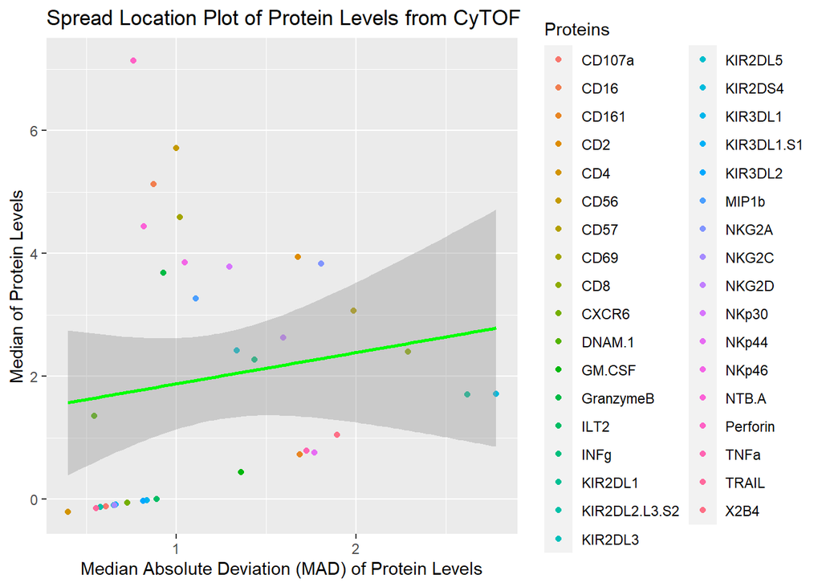

```r
ggplot(
  data = proteinMedianDF,
  aes(
    x = medianAbsoluteDeviation,
    y = medianProteinLevel,
    color = Proteins)) +
  geom_point() +
  geom_smooth(
    method = "lm",
    color = "green") +
  xlab("Median Absolute Deviation (MAD) of Protein Levels") +
  ylab("Median of Protein Levels") +
  ggtitle("Spread Location Plot of Protein Levels from CyTOF")
```

```r
gymData <- example_gymnastics_2
gymData
```

```
## # A tibble: 3 × 5
##   country       vault_2012 floor_2012 vault_2016 floor_2016
##   <chr>              <dbl>      <dbl>      <dbl>      <dbl>
## 1 United States       48.1       45.4       46.9       46.0
## 2 Russia              46.4       41.6       45.7       42.0
## 3 China               44.3       40.8       44.3       42.1
```

Using either pivot_longer on its own or pivot_longer in combination with separate, reshape the dataset so that it has columns for country, event, year, and score.

```r
gymCol <- colnames(gymData)

gymDataL <- gymData %>%
  pivot_longer(
    cols = !country,
    names_to = c("Event", "Year"),
    names_sep = "_",
    names_transform = list(Year = as.integer),
    values_to = "Score")
gymDataL
```

```
## # A tibble: 12 × 4
##    country       Event  Year Score
##    <chr>         <chr> <int> <dbl>
##  1 United States vault  2012  48.1
##  2 United States floor  2012  45.4
##  3 United States vault  2016  46.9
##  4 United States floor  2016  46.0
##  5 Russia        vault  2012  46.4
##  6 Russia        floor  2012  41.6
##  7 Russia        vault  2016  45.7
##  8 Russia        floor  2016  42.0
##  9 China         vault  2012  44.3
## 10 China         floor  2012  40.8
## 11 China         vault  2016  44.3
## 12 China         floor  2016  42.1
```